# Project: Explore the movie industry, the last fifty years.

- Introduction
- Data Wrangling
- Exploratory Data Analysis
- Conclusions

## Introduction

```python
# import pandas, numpy, seaborn and matplotlib

import pandas as pd
import numpy as np
import seaborn as sns
import matplotlib.pyplot as plt
%matplotlib inline
```

## Data Wrangling

### General Properties

First, let's load the data set as a pandas DataFrame and have look at it to understand the structure.

```python
# Load tmdb movies data set and print out first few lines.
df_tmdb = pd.read_csv('tmdb_v0.csv')
df_tmdb.head()
```

|  | id | imdb_id | popularity | budget | revenue | original_title | cast | homepage | director | tagline | ... | overview | runtime | genres | production_companies | release_date | vote_count | vote_average | release_year | budget_adj | revenue_adj |
| --- | --- | --- | --- | --- | --- | --- | --- | --- | --- | --- | --- | --- | --- | --- | --- | --- | --- | --- | --- | --- | --- |
| 0 | 135397 | tt0369610 | 32.985763 | 150000000 | 1513528810 | Jurassic World | Chris Pratt\|Bryce Dallas Howard\|Irrfan Khan\|Vi... | http://www.jurassicworld.com/ | Colin Trevorrow | The park is open. | ... | Twenty-two years after the events of Jurassic ... | 124 | Action\|Adventure\|Science Fiction\|Thriller | Universal Studios\|Amblin Entertainment\|Legenda... | 6/9/15 | 5562 | 6.5 | 2015 | 1.379999e+08 | 1.392446e+09 |
| 1 | 76341 | tt1392190 | 28.419936 | 150000000 | 378436354 | Mad Max: Fury Road | Tom Hardy\|Charlize Theron\|Hugh Keays-Byrne\|Nic... | http://www.madmaxmovie.com/ | George Miller | What a Lovely Day. | ... | An apocalyptic story set in the furthest reach... | 120 | Action\|Adventure\|Science Fiction\|Thriller | Village Roadshow Pictures\|Kennedy Miller Produ... | 5/13/15 | 6185 | 7.1 | 2015 | 1.379999e+08 | 3.481613e+08 |
| 2 | 262500 | tt2908446 | 13.112507 | 110000000 | 295238201 | Insurgent | Shailene Woodley\|Theo James\|Kate Winslet\|Ansel... | http://www.thedivergentseries.movie/#insurgent | Robert Schwentke | One Choice Can Destroy You | ... | Beatrice Prior must confront her inner demons ... | 119 | Adventure\|Science Fiction\|Thriller | Summit Entertainment\|Mandeville Films\|Red Wago... | 3/18/15 | 2480 | 6.3 | 2015 | 1.012000e+08 | 2.716190e+08 |
| 3 | 140607 | tt2488496 | 11.173104 | 200000000 | 2068178225 | Star Wars: The Force Awakens | Harrison Ford\|Mark Hamill\|Carrie Fisher\|Adam D... | http://www.starwars.com/films/star-wars-episod... | J.J. Abrams | Every generation has a story. | ... | Thirty years after defeating the Galactic Empi... | 136 | Action\|Adventure\|Science Fiction\|Fantasy | Lucasfilm\|Truenorth Productions\|Bad Robot | 12/15/15 | 5292 | 7.5 | 2015 | 1.839999e+08 | 1.902723e+09 |
| 4 | 168259 | tt2820852 | 9.335014 | 190000000 | 1506249360 | Furious 7 | Vin Diesel\|Paul Walker\|Jason Statham\|Michelle ... | http://www.furious7.com/ | James Wan | Vengeance Hits Home | ... | Deckard Shaw seeks revenge against Dominic Tor... | 137 | Action\|Crime\|Thriller | Universal Pictures\|Original Film\|Media Rights ... | 4/1/15 | 2947 | 7.3 | 2015 | 1.747999e+08 | 1.385749e+09 |

5 rows × 21 columns

```python
df_tmdb.info()
```

```
<class 'pandas.core.frame.DataFrame'>
RangeIndex: 10866 entries, 0 to 10865
Data columns (total 21 columns):
id                      10866 non-null int64
imdb_id                 10856 non-null object
popularity              10866 non-null float64
budget                  10866 non-null int64
revenue                 10866 non-null int64
original_title          10866 non-null object
cast                    10790 non-null object
homepage                2936 non-null object
director                10822 non-null object
tagline                 8042 non-null object
keywords                9373 non-null object
overview                10862 non-null object
runtime                 10866 non-null int64
genres                  10843 non-null object
production_companies    9836 non-null object
release_date            10866 non-null object
vote_count              10866 non-null int64
vote_average            10866 non-null float64
release_year            10866 non-null int64
budget_adj              10866 non-null float64
revenue_adj             10866 non-null float64
dtypes: float64(4), int64(6), object(11)
memory usage: 1.7+ MB
```

### Data Cleaning

There are 21 columns and 10866 rows in this data set. Some of these columns have large amount of non-replaceable missing values. Luckily, these columns are irrelevant for this study. There are some columns such as *id* and *overview* that are irrelevant for the study despite having complete data.  
In addition, it is more reasonable to use adjusted budget and revenue for the investigation than revenue and budget. The adjusted columns *(budget_adj and revenue_adj)* show the budget and revenue of the associated movie in terms of 2010 dollars, accounting for inflation over time. Due to those reasons the following set of columns will be removed from the data frame.

```python
# Remove columns
df_tmdb.drop(['id', 'imdb_id', 'budget', 'revenue', 'cast', 'homepage', 'tagline', 'keywords', 'overview', 'production_companies'], axis=1, inplace=True)
```

```python
# Inspect the columns again
df_tmdb.info()
```

```
<class 'pandas.core.frame.DataFrame'>
RangeIndex: 10866 entries, 0 to 10865
Data columns (total 11 columns):
popularity        10866 non-null float64
original_title    10866 non-null object
director          10822 non-null object
runtime           10866 non-null int64
genres            10843 non-null object
release_date      10866 non-null object
vote_count        10866 non-null int64
vote_average      10866 non-null float64
release_year      10866 non-null int64
budget_adj        10866 non-null float64
revenue_adj       10866 non-null float64
dtypes: float64(4), int64(3), object(4)
memory usage: 933.9+ KB
```

```python
# Remove rows with null value points
df_tmdb.dropna(inplace=True)
# Inspect the info again
df_tmdb.info()
```

```
<class 'pandas.core.frame.DataFrame'>
Int64Index: 10801 entries, 0 to 10865
Data columns (total 11 columns):
popularity        10801 non-null float64
original_title    10801 non-null object
director          10801 non-null object
runtime           10801 non-null int64
genres            10801 non-null object
release_date      10801 non-null object
vote_count        10801 non-null int64
vote_average      10801 non-null float64
release_year      10801 non-null int64
budget_adj        10801 non-null float64
revenue_adj       10801 non-null float64
dtypes: float64(4), int64(3), object(4)
memory usage: 1012.6+ KB
```

```python
# Check for duplicate rows
sum(df_tmdb.duplicated())
```

```
1
```

There is one duplicate row that need to be romoved.

```python
# Remove the duplicate row
df_tmdb.drop_duplicates(inplace=True)
```

```python
# Let's examine the statistics of numerical data
df_tmdb.describe()
```

|  | popularity | runtime | vote_count | vote_average | release_year | budget_adj | revenue_adj |
| --- | --- | --- | --- | --- | --- | --- | --- |
| count | 10800.000000 | 10800.000000 | 10800.000000 | 10800.000000 | 10800.000000 | 1.080000e+04 | 1.080000e+04 |
| mean | 0.649455 | 102.189722 | 218.600741 | 5.970880 | 2001.289537 | 1.765437e+07 | 5.167714e+07 |
| std | 1.002441 | 30.783873 | 577.165055 | 0.933006 | 12.819545 | 3.438403e+07 | 1.450182e+08 |
| min | 0.000188 | 0.000000 | 10.000000 | 1.500000 | 1960.000000 | 0.000000e+00 | 0.000000e+00 |
| 25% | 0.209157 | 90.000000 | 17.000000 | 5.400000 | 1995.000000 | 0.000000e+00 | 0.000000e+00 |
| 50% | 0.385471 | 99.000000 | 39.000000 | 6.000000 | 2006.000000 | 0.000000e+00 | 0.000000e+00 |
| 75% | 0.717508 | 111.250000 | 147.000000 | 6.600000 | 2011.000000 | 2.103337e+07 | 3.408743e+07 |
| max | 32.985763 | 900.000000 | 9767.000000 | 9.200000 | 2015.000000 | 4.250000e+08 | 2.827124e+09 |

It seems that there are zero values in both *'budget_adj'* and *'revenue_adj'*. Also there are some zero values in *'runtime'* too. These rows need to be removed from the DataFrame.

```python
# Replace any 0 values with nan
df_tmdb.replace(0, np.nan, inplace=True)
# Remove rows with nulls
df_tmdb.dropna(inplace=True)
```

```python
df_tmdb.describe()
```

|  | popularity | runtime | vote_count | vote_average | release_year | budget_adj | revenue_adj |
| --- | --- | --- | --- | --- | --- | --- | --- |
| count | 3853.000000 | 3853.000000 | 3853.000000 | 3853.000000 | 3853.000000 | 3.853000e+03 | 3.853000e+03 |
| mean | 1.191825 | 109.208928 | 527.854399 | 6.168258 | 2001.259278 | 4.425038e+07 | 1.370974e+08 |
| std | 1.475258 | 19.912913 | 880.031643 | 0.795001 | 11.283517 | 4.481043e+07 | 2.161299e+08 |
| min | 0.001117 | 15.000000 | 10.000000 | 2.200000 | 1960.000000 | 9.693980e-01 | 2.370705e+00 |
| 25% | 0.462609 | 95.000000 | 71.000000 | 5.700000 | 1995.000000 | 1.309053e+07 | 1.840420e+07 |
| 50% | 0.797723 | 106.000000 | 204.000000 | 6.200000 | 2004.000000 | 3.001664e+07 | 6.174274e+07 |
| 75% | 1.368403 | 119.000000 | 580.000000 | 6.700000 | 2010.000000 | 6.061307e+07 | 1.632752e+08 |
| max | 32.985763 | 338.000000 | 9767.000000 | 8.400000 | 2015.000000 | 4.250000e+08 | 2.827124e+09 |

```python
df_tmdb.info()
```

```
<class 'pandas.core.frame.DataFrame'>
Int64Index: 3853 entries, 0 to 10848
Data columns (total 11 columns):
popularity        3853 non-null float64
original_title    3853 non-null object
director          3853 non-null object
runtime           3853 non-null float64
genres            3853 non-null object
release_date      3853 non-null object
vote_count        3853 non-null int64
vote_average      3853 non-null float64
release_year      3853 non-null int64
budget_adj        3853 non-null float64
revenue_adj       3853 non-null float64
dtypes: float64(5), int64(2), object(4)
memory usage: 361.2+ KB
```

There are 3853 rows, however the indexes are going from 0 to 10848. Threfore, the indexes need to be fixed.

```python
# Let's look at the last five rows to confirm this.
df_tmdb.tail()
```

|  | popularity | original_title | director | runtime | genres | release_date | vote_count | vote_average | release_year | budget_adj | revenue_adj |
| --- | --- | --- | --- | --- | --- | --- | --- | --- | --- | --- | --- |
| 10822 | 0.670274 | Who's Afraid of Virginia Woolf? | Mike Nichols | 131.0 | Drama | 6/21/66 | 74 | 7.5 | 1966 | 5.038511e+07 | 2.266436e+08 |
| 10828 | 0.402730 | Torn Curtain | Alfred Hitchcock | 128.0 | Mystery\|Thriller | 7/13/66 | 46 | 6.3 | 1966 | 2.015404e+07 | 8.733419e+07 |
| 10829 | 0.395668 | El Dorado | Howard Hawks | 120.0 | Action\|Western | 12/17/66 | 36 | 6.9 | 1966 | 3.125892e+07 | 4.030809e+07 |
| 10835 | 0.299911 | The Sand Pebbles | Robert Wise | 182.0 | Action\|Adventure\|Drama\|War\|Romance | 12/20/66 | 28 | 7.0 | 1966 | 8.061618e+07 | 1.343603e+08 |
| 10848 | 0.207257 | Fantastic Voyage | Richard Fleischer | 100.0 | Adventure\|Science Fiction | 8/24/66 | 42 | 6.7 | 1966 | 3.436265e+07 | 8.061618e+07 |

```python
# Fix indexes
df_tmdb.reset_index(drop=True, inplace=True)
# Inspect the info again
df_tmdb.info()
```

```
<class 'pandas.core.frame.DataFrame'>
RangeIndex: 3853 entries, 0 to 3852
Data columns (total 11 columns):
popularity        3853 non-null float64
original_title    3853 non-null object
director          3853 non-null object
runtime           3853 non-null float64
genres            3853 non-null object
release_date      3853 non-null object
vote_count        3853 non-null int64
vote_average      3853 non-null float64
release_year      3853 non-null int64
budget_adj        3853 non-null float64
revenue_adj       3853 non-null float64
dtypes: float64(5), int64(2), object(4)
memory usage: 331.2+ KB
```

```python
# Let's look at the last five row indexes to confirm fixing.
df_tmdb.tail()
```

|  | popularity | original_title | director | runtime | genres | release_date | vote_count | vote_average | release_year | budget_adj | revenue_adj |
| --- | --- | --- | --- | --- | --- | --- | --- | --- | --- | --- | --- |
| 3848 | 0.670274 | Who's Afraid of Virginia Woolf? | Mike Nichols | 131.0 | Drama | 6/21/66 | 74 | 7.5 | 1966 | 5.038511e+07 | 2.266436e+08 |
| 3849 | 0.402730 | Torn Curtain | Alfred Hitchcock | 128.0 | Mystery\|Thriller | 7/13/66 | 46 | 6.3 | 1966 | 2.015404e+07 | 8.733419e+07 |
| 3850 | 0.395668 | El Dorado | Howard Hawks | 120.0 | Action\|Western | 12/17/66 | 36 | 6.9 | 1966 | 3.125892e+07 | 4.030809e+07 |
| 3851 | 0.299911 | The Sand Pebbles | Robert Wise | 182.0 | Action\|Adventure\|Drama\|War\|Romance | 12/20/66 | 28 | 7.0 | 1966 | 8.061618e+07 | 1.343603e+08 |
| 3852 | 0.207257 | Fantastic Voyage | Richard Fleischer | 100.0 | Adventure\|Science Fiction | 8/24/66 | 42 | 6.7 | 1966 | 3.436265e+07 | 8.061618e+07 |

Now I have a DataFrame with all the essential data columns without nulls, zero values where zero values are not applicable and duplicates. Now we need to split the *'genres'* and *'director'* columns to their individual componants which are separated by a '|' character. We can build a function to do that.

```python
# This function takes a pandas Series or a Dataframe column as an argument
# Separate strings between '|'
# Return a stacked series

def separate(data):
    return data.str[0:].str.split('|', expand = True).stack()
```

```python
# Separate genres column and join it to the dataframe.
# Use separate function above to split the string.
df_tmdb = df_tmdb.join(separate(df_tmdb.genres).reset_index(level=1,drop=True).rename('genre')).reset_index(drop=True)
```

```python
# Separate director column and join it to the dataframe.
# Use separate function above to split the string.
df_tmdb = df_tmdb.join(separate(df_tmdb.director).reset_index(level=1,drop=True).rename('directors')).reset_index(drop=True)
```

```python
df_tmdb.head()
```

|  | popularity | original_title | director | runtime | genres | release_date | vote_count | vote_average | release_year | budget_adj | revenue_adj | genre | directors |
| --- | --- | --- | --- | --- | --- | --- | --- | --- | --- | --- | --- | --- | --- |
| 0 | 32.985763 | Jurassic World | Colin Trevorrow | 124.0 | Action\|Adventure\|Science Fiction\|Thriller | 6/9/15 | 5562 | 6.5 | 2015 | 1.379999e+08 | 1.392446e+09 | Action | Colin Trevorrow |
| 1 | 32.985763 | Jurassic World | Colin Trevorrow | 124.0 | Action\|Adventure\|Science Fiction\|Thriller | 6/9/15 | 5562 | 6.5 | 2015 | 1.379999e+08 | 1.392446e+09 | Adventure | Colin Trevorrow |
| 2 | 32.985763 | Jurassic World | Colin Trevorrow | 124.0 | Action\|Adventure\|Science Fiction\|Thriller | 6/9/15 | 5562 | 6.5 | 2015 | 1.379999e+08 | 1.392446e+09 | Science Fiction | Colin Trevorrow |
| 3 | 32.985763 | Jurassic World | Colin Trevorrow | 124.0 | Action\|Adventure\|Science Fiction\|Thriller | 6/9/15 | 5562 | 6.5 | 2015 | 1.379999e+08 | 1.392446e+09 | Thriller | Colin Trevorrow |
| 4 | 28.419936 | Mad Max: Fury Road | George Miller | 120.0 | Action\|Adventure\|Science Fiction\|Thriller | 5/13/15 | 6185 | 7.1 | 2015 | 1.379999e+08 | 3.481613e+08 | Action | George Miller |

```python
# Now remove the original genres and director columns
df_tmdb.drop(['genres', 'director'], axis=1, inplace=True)
```

```python
df_tmdb.head()
```

|  | popularity | original_title | runtime | release_date | vote_count | vote_average | release_year | budget_adj | revenue_adj | genre | directors |
| --- | --- | --- | --- | --- | --- | --- | --- | --- | --- | --- | --- |
| 0 | 32.985763 | Jurassic World | 124.0 | 6/9/15 | 5562 | 6.5 | 2015 | 1.379999e+08 | 1.392446e+09 | Action | Colin Trevorrow |
| 1 | 32.985763 | Jurassic World | 124.0 | 6/9/15 | 5562 | 6.5 | 2015 | 1.379999e+08 | 1.392446e+09 | Adventure | Colin Trevorrow |
| 2 | 32.985763 | Jurassic World | 124.0 | 6/9/15 | 5562 | 6.5 | 2015 | 1.379999e+08 | 1.392446e+09 | Science Fiction | Colin Trevorrow |
| 3 | 32.985763 | Jurassic World | 124.0 | 6/9/15 | 5562 | 6.5 | 2015 | 1.379999e+08 | 1.392446e+09 | Thriller | Colin Trevorrow |
| 4 | 28.419936 | Mad Max: Fury Road | 120.0 | 5/13/15 | 6185 | 7.1 | 2015 | 1.379999e+08 | 3.481613e+08 | Action | George Miller |

```python
# Extract the month from the release_date column add it as a new column 'release_month'
df_tmdb['release_month'] = pd.DatetimeIndex(df_tmdb['release_date']).month

# Remove release_date column
df_tmdb.drop(['release_date'], axis=1, inplace=True)
```

```python
df_tmdb.head()
```

|  | popularity | original_title | runtime | vote_count | vote_average | release_year | budget_adj | revenue_adj | genre | directors | release_month |
| --- | --- | --- | --- | --- | --- | --- | --- | --- | --- | --- | --- |
| 0 | 32.985763 | Jurassic World | 124.0 | 5562 | 6.5 | 2015 | 1.379999e+08 | 1.392446e+09 | Action | Colin Trevorrow | 6 |
| 1 | 32.985763 | Jurassic World | 124.0 | 5562 | 6.5 | 2015 | 1.379999e+08 | 1.392446e+09 | Adventure | Colin Trevorrow | 6 |
| 2 | 32.985763 | Jurassic World | 124.0 | 5562 | 6.5 | 2015 | 1.379999e+08 | 1.392446e+09 | Science Fiction | Colin Trevorrow | 6 |
| 3 | 32.985763 | Jurassic World | 124.0 | 5562 | 6.5 | 2015 | 1.379999e+08 | 1.392446e+09 | Thriller | Colin Trevorrow | 6 |
| 4 | 28.419936 | Mad Max: Fury Road | 120.0 | 6185 | 7.1 | 2015 | 1.379999e+08 | 3.481613e+08 | Action | George Miller | 5 |

```python
# Create a new column 'profit' = 'revenue_adj' - budget_adj
df_tmdb['profit'] = df_tmdb['revenue_adj'].sub(df_tmdb['budget_adj'], axis=0)
# Remove 'revenue_adj' column
df_tmdb.drop(['revenue_adj'], axis=1, inplace=True)
```

```python
df_tmdb.head()
```

|  | popularity | original_title | runtime | vote_count | vote_average | release_year | budget_adj | genre | directors | release_month | profit |
| --- | --- | --- | --- | --- | --- | --- | --- | --- | --- | --- | --- |
| 0 | 32.985763 | Jurassic World | 124.0 | 5562 | 6.5 | 2015 | 1.379999e+08 | Action | Colin Trevorrow | 6 | 1.254446e+09 |
| 1 | 32.985763 | Jurassic World | 124.0 | 5562 | 6.5 | 2015 | 1.379999e+08 | Adventure | Colin Trevorrow | 6 | 1.254446e+09 |
| 2 | 32.985763 | Jurassic World | 124.0 | 5562 | 6.5 | 2015 | 1.379999e+08 | Science Fiction | Colin Trevorrow | 6 | 1.254446e+09 |
| 3 | 32.985763 | Jurassic World | 124.0 | 5562 | 6.5 | 2015 | 1.379999e+08 | Thriller | Colin Trevorrow | 6 | 1.254446e+09 |
| 4 | 28.419936 | Mad Max: Fury Road | 120.0 | 6185 | 7.1 | 2015 | 1.379999e+08 | Action | George Miller | 5 | 2.101614e+08 |

Now we have cleaned DataFrame for the exploration of our research problems.

## Exploratory Data Analysis

### Research Question 1: What is the most popular movie genre in each year?

Using our DataFrame *'df_tmdb'*, let's calculate the mean popularity for each genre for each year.

```python
# Calculate the mean popularity for each genre for each year.
mean_pop = df_tmdb.groupby(['release_year', 'genre'])['popularity'].mean()
mean_pop
```

```
release_year  genre
1960          Action             1.504538
              Adventure          1.872132
              Comedy             0.501564
              Drama              1.564871
              History            1.136943
              Horror             2.610362
              Romance            0.501564
              Thriller           2.610362
              Western            1.872132
1961          Action             0.560942
              Adventure          1.881011
              Animation          2.631987
              Comedy             1.707009
              Crime              0.900245
              Drama              0.771616
              Family             2.049936
              History            0.538364
              Horror             0.249542
              Music              0.900245
              Romance            1.752027
              War                0.754548
              Western            0.173731
1962          Action             1.055017
              Adventure          1.073975
              Crime              0.810805
              Drama              0.598124
              History            1.168767
              Thriller           3.170651
              War                1.168767
              Western            0.522302
                                   ...
2014          Crime              2.057937
              Drama              2.045836
              Family             2.744622
              Fantasy            3.746498
              History            3.321015
              Horror             1.142637
              Music              2.493149
              Mystery            2.781021
```

[output cut: 8 more lines]

```
              Comedy             2.161175
              Crime              2.881727
              Drama              2.015135
              Family             3.661806
              Fantasy            3.530748
              History            2.258394
              Horror             1.451558
              Music              1.391390
              Mystery            2.668201
              Romance            2.073257
              Science Fiction    7.533539
              Thriller           3.842955
              War                1.943238
              Western            7.504550
Name: popularity, Length: 842, dtype: float64
```

```python
type(mean_pop)
```

```
pandas.core.series.Series
```

```python
# Convert the Series 'mean_pop' to a DataFrame
df_mean_pop = mean_pop.to_frame()
df_mean_pop.head()
```

| release_year | genre | popularity |
| --- | --- | --- |
| 1960 | Action | 1.504538 |
|  | Adventure | 1.872132 |
|  | Comedy | 0.501564 |
|  | Drama | 1.564871 |
|  | History | 1.136943 |

```python
# Fix index
df_mean_pop.reset_index(inplace=True)
df_mean_pop.head()
```

|  | release_year | genre | popularity |
| --- | --- | --- | --- |
| 0 | 1960 | Action | 1.504538 |
| 1 | 1960 | Adventure | 1.872132 |
| 2 | 1960 | Comedy | 0.501564 |
| 3 | 1960 | Drama | 1.564871 |
| 4 | 1960 | History | 1.136943 |

```python
# Create a pivot table
pop = df_mean_pop.pivot('release_year', 'genre', 'popularity')
pop.head()
```

| genre release_year | Action | Adventure | Animation | Comedy | Crime | Documentary | Drama | Family | Fantasy | Foreign | History | Horror | Music | Mystery | Romance | Science Fiction | TV Movie | Thriller | War | Western |
| --- | --- | --- | --- | --- | --- | --- | --- | --- | --- | --- | --- | --- | --- | --- | --- | --- | --- | --- | --- | --- |
| 1960 | 1.504538 | 1.872132 | NaN | 0.501564 | NaN | NaN | 1.564871 | NaN | NaN | NaN | 1.136943 | 2.610362 | NaN | NaN | 0.501564 | NaN | NaN | 2.610362 | NaN | 1.872132 |
| 1961 | 0.560942 | 1.881011 | 2.631987 | 1.707009 | 0.900245 | NaN | 0.771616 | 2.049936 | NaN | NaN | 0.538364 | 0.249542 | 0.900245 | NaN | 1.752027 | NaN | NaN | NaN | 0.754548 | 0.173731 |
| 1962 | 1.055017 | 1.073975 | NaN | NaN | 0.810805 | NaN | 0.598124 | NaN | NaN | NaN | 1.168767 | NaN | NaN | NaN | NaN | NaN | NaN | 3.170651 | 1.168767 | 0.522302 |
| 1963 | 0.974186 | 1.586280 | NaN | 0.920094 | NaN | NaN | 0.582041 | NaN | NaN | NaN | 0.582041 | 1.139321 | NaN | 0.920094 | 0.833423 | NaN | NaN | 1.364218 | 0.664326 | NaN |
| 1964 | 3.153791 | 3.153791 | NaN | 1.670163 | 0.663446 | NaN | 0.922681 | 1.310850 | 1.987819 | NaN | NaN | NaN | 1.144632 | 0.663446 | 0.408402 | NaN | NaN | 1.908618 | 2.210475 | NaN |

Now we have a table (technically a DataFrame, 'pop') that summarizes the mean popularity of each movie genre for each year (rows) from 1960 to 2015. With this table we can find the most popular movie genre for each year. To do that we can find the max value for each row (same as each year) and store it in a new column called *'popularity'* and store the column name (the genre) that hold the max value in another column called *'genre'*.

```python
# Find the most popular genre in each row and store in the new column
# This basically, find the column name of the max value in rows.
pop['genre']=pop.idxmax(axis=1)

# Find the maximum popularity (the average) in each row and store in the new column
pop['popularity']=pop.max(axis=1)
```

```python
pop.head()
```

| genre release_year | Action | Adventure | Animation | Comedy | Crime | Documentary | Drama | Family | Fantasy | Foreign | ... | Music | Mystery | Romance | Science Fiction | TV Movie | Thriller | War | Western | genre | popularity |
| --- | --- | --- | --- | --- | --- | --- | --- | --- | --- | --- | --- | --- | --- | --- | --- | --- | --- | --- | --- | --- | --- |
| 1960 | 1.504538 | 1.872132 | NaN | 0.501564 | NaN | NaN | 1.564871 | NaN | NaN | NaN | ... | NaN | NaN | 0.501564 | NaN | NaN | 2.610362 | NaN | 1.872132 | Horror | 2.610362 |
| 1961 | 0.560942 | 1.881011 | 2.631987 | 1.707009 | 0.900245 | NaN | 0.771616 | 2.049936 | NaN | NaN | ... | 0.900245 | NaN | 1.752027 | NaN | NaN | NaN | 0.754548 | 0.173731 | Animation | 2.631987 |
| 1962 | 1.055017 | 1.073975 | NaN | NaN | 0.810805 | NaN | 0.598124 | NaN | NaN | NaN | ... | NaN | NaN | NaN | NaN | NaN | 3.170651 | 1.168767 | 0.522302 | Thriller | 3.170651 |
| 1963 | 0.974186 | 1.586280 | NaN | 0.920094 | NaN | NaN | 0.582041 | NaN | NaN | NaN | ... | NaN | 0.920094 | 0.833423 | NaN | NaN | 1.364218 | 0.664326 | NaN | Adventure | 1.586280 |
| 1964 | 3.153791 | 3.153791 | NaN | 1.670163 | 0.663446 | NaN | 0.922681 | 1.310850 | 1.987819 | NaN | ... | 1.144632 | 0.663446 | 0.408402 | NaN | NaN | 1.908618 | 2.210475 | NaN | Action | 3.153791 |

5 rows × 22 columns

The two new columns have been added at the end of the table. Before proceed, we need to fix the index column. to do that we can first convert this pivot table to a record format and then convert back into a DataFrame. Similar to what explained in **[here](https://stackoverflow.com/questions/42708193/pandas-pivot-table-to-data-frame)**.

```python
# Convert pivot table to a DataFrame
df_pop = pd.DataFrame(pop.to_records())
df_pop
```

|  | release_year | Action | Adventure | Animation | Comedy | Crime | Documentary | Drama | Family | Fantasy | ... | Music | Mystery | Romance | Science Fiction | TV Movie | Thriller | War | Western | genre | popularity |
| --- | --- | --- | --- | --- | --- | --- | --- | --- | --- | --- | --- | --- | --- | --- | --- | --- | --- | --- | --- | --- | --- |
| 0 | 1960 | 1.504538 | 1.872132 | NaN | 0.501564 | NaN | NaN | 1.564871 | NaN | NaN | ... | NaN | NaN | 0.501564 | NaN | NaN | 2.610362 | NaN | 1.872132 | Horror | 2.610362 |
| 1 | 1961 | 0.560942 | 1.881011 | 2.631987 | 1.707009 | 0.900245 | NaN | 0.771616 | 2.049936 | NaN | ... | 0.900245 | NaN | 1.752027 | NaN | NaN | NaN | 0.754548 | 0.173731 | Animation | 2.631987 |
| 2 | 1962 | 1.055017 | 1.073975 | NaN | NaN | 0.810805 | NaN | 0.598124 | NaN | NaN | ... | NaN | NaN | NaN | NaN | NaN | 3.170651 | 1.168767 | 0.522302 | Thriller | 3.170651 |
| 3 | 1963 | 0.974186 | 1.586280 | NaN | 0.920094 | NaN | NaN | 0.582041 | NaN | NaN | ... | NaN | 0.920094 | 0.833423 | NaN | NaN | 1.364218 | 0.664326 | NaN | Adventure | 1.586280 |
| 4 | 1964 | 3.153791 | 3.153791 | NaN | 1.670163 | 0.663446 | NaN | 0.922681 | 1.310850 | 1.987819 | ... | 1.144632 | 0.663446 | 0.408402 | NaN | NaN | 1.908618 | 2.210475 | NaN | Action | 3.153791 |
| 5 | 1965 | 1.266311 | 1.266311 | NaN | 0.622157 | NaN | NaN | 0.913921 | 1.313676 | NaN | ... | 1.313676 | NaN | 1.297865 | NaN | NaN | 1.910465 | 1.282053 | NaN | Thriller | 1.910465 |
| 6 | 1966 | 0.347789 | 0.253584 | NaN | NaN | NaN | NaN | 0.485092 | NaN | NaN | ... | NaN | 0.402730 | 0.299911 | 0.207257 | NaN | 0.402730 | 0.299911 | 0.395668 | Drama | 0.485092 |
| 7 | 1967 | 1.702374 | 1.634289 | 2.550704 | 1.420146 | 0.678960 | NaN | 0.782614 | 1.395994 | 0.241283 | ... | 0.227287 | 0.428652 | 0.719199 | NaN | NaN | 0.856507 | 0.485288 | NaN | Animation | 2.550704 |
| 8 | 1968 | 0.678138 | 1.677185 | NaN | NaN | 0.786854 | NaN | 0.522972 | 0.633129 | NaN | ... | 0.633129 | 1.728887 | 0.045242 | 1.502458 | NaN | 0.786854 | 0.474040 | 0.621202 | Mystery | 1.728887 |
| 9 | 1969 | 1.778746 | 1.197318 | NaN | NaN | 1.357317 | NaN | 1.108561 | NaN | NaN | ... | NaN | NaN | NaN | NaN | NaN | 1.778746 | NaN | 0.986603 | Action | 1.778746 |
| 10 | 1970 | 0.327371 | 0.717916 | 1.936962 | 0.713495 | 0.429246 | NaN | 0.403361 | 1.936962 | NaN | ... | NaN | 0.613239 | 0.368118 | 0.797231 | NaN | 0.336237 | 0.465747 | 0.241966 | Animation | 1.936962 |
| 11 | 1971 | 0.783304 | 1.036521 | NaN | NaN | 0.620646 | NaN | 0.847440 | 2.430667 | 2.430667 | ... | 0.291077 | 0.681563 | 0.425782 | 1.579311 | NaN | 0.720226 | NaN | NaN | Family | 2.430667 |
| 12 | 1972 | 0.446170 | 0.530554 | NaN | 0.406607 | 2.199242 | NaN | 2.428841 | NaN | NaN | ... | NaN | 0.599109 | NaN | 0.881814 | NaN | 0.603025 | NaN | NaN | Drama | 2.428841 |
| 13 | 1973 | 0.871426 | 1.549139 | 2.272486 | 0.705212 | 0.685407 | NaN | 0.830599 | 2.272486 | NaN | ... | NaN | NaN | 0.568400 | 0.722452 | NaN | 1.517646 | NaN | NaN | Animation | 2.272486 |
| 14 | 1974 | 0.552036 | 1.041446 | NaN | 0.813881 | 1.298649 | NaN | 0.939476 | NaN | NaN | ... | NaN | 1.206313 | 0.372231 | 1.049959 | NaN | 0.779041 | NaN | 0.577802 | Crime | 1.298649 |
| 15 | 1975 | NaN | 2.344366 | NaN | 1.667707 | 0.277357 | NaN | 1.065191 | NaN | 2.234953 | ... | 0.878534 | NaN | 1.019569 | 1.409947 | NaN | 1.420274 | 1.019569 | NaN | Adventure | 2.344366 |
| 16 | 1976 | 0.844386 | 0.905449 | NaN | 0.326138 | 1.301804 | NaN | 1.134102 | 0.017498 | NaN | ... | 0.155768 | 0.605255 | 0.539918 | 0.905449 | NaN | 0.826390 | NaN | 0.597297 | Crime | 1.301804 |
| 17 | 1977 | 2.709534 | 2.349853 | 1.333453 | 0.870240 | 0.495480 | NaN | 0.617393 | 1.477351 | 0.970349 | ... | 0.581844 | 0.191541 | 1.179653 | 2.427533 | NaN | 0.672588 | 1.048838 | NaN | Action | 2.709534 |
| 18 | 1978 | 0.494843 | 0.529087 | 0.361015 | 0.784878 | 0.512719 | NaN | 0.439741 | 0.277769 | 0.744046 | ... | 0.987694 | 0.439124 | NaN | 0.632490 | NaN | 0.679771 | 0.697533 | NaN | Music | 0.987694 |
| 19 | 1979 | 1.661789 | 1.240556 | NaN | 0.720105 | 0.567776 | NaN | 0.865772 | 0.338280 | NaN | ... | NaN | 1.823058 | 0.973049 | 1.962286 | NaN | 2.266502 | 2.319520 | NaN | Horror | 2.865282 |
| 20 | 1980 | 1.876256 | 2.722343 | NaN | 1.140993 | 0.712956 | NaN | 0.634475 | NaN | 0.585804 | ... | 0.868761 | 0.374639 | 0.901413 | 1.621084 | NaN | 0.767885 | NaN | 0.273592 | Adventure | 2.722343 |
| 21 | 1981 | 1.548196 | 1.506690 | 1.278646 | 0.716218 | 0.251658 | NaN | 0.671823 | 0.891076 | 0.304373 | ... | NaN | 0.376821 | 0.962698 | 0.679185 | NaN | 0.676421 | NaN | NaN | Action | 1.548196 |
| 22 | 1982 | 0.974906 | 1.489252 | 0.555585 | 0.685966 | 0.813065 | NaN | 0.924049 | 1.088416 | 1.140767 | ... | 0.448761 | 1.332925 | 0.428907 | 1.815975 | NaN | 1.506857 | 1.143183 | 0.138162 | Science Fiction | 1.815975 |
| 23 | 1983 | 1.476677 | 1.548183 | 0.394400 | 0.937964 | 0.928809 | NaN | 0.610949 | 0.592219 | 0.421248 | ... | 0.376409 | 0.203487 | 0.534747 | 0.778998 | NaN | 0.732690 | NaN | 0.290596 | Adventure | 1.548183 |
| 24 | 1984 | 1.232622 | 1.022069 | NaN | 0.832778 | 1.019744 | 0.283191 | 0.812984 | 1.819898 | 1.247944 | ... | 0.652252 | 0.517691 | 0.630121 | 1.226851 | NaN | 1.107832 | 0.482891 | NaN | Family | 1.819898 |
| 25 | 1985 | 0.948277 | 1.261361 | 1.034373 | 1.004920 | 0.780787 | NaN | 0.909043 | 1.526121 | 0.818179 | ... | NaN | 0.688022 | 0.558524 | 1.481361 | NaN | 0.748479 | 0.696623 | NaN | Family | 1.526121 |
| 26 | 1986 | 0.881183 | 0.807151 | 1.136303 | 0.607881 | 0.563147 | NaN | 0.780212 | 0.559951 | 0.778104 | ... | 0.532029 | 0.808365 | 0.642521 | 0.788763 | NaN | 0.819857 | 1.095808 | NaN | Animation | 1.136303 |
| 27 | 1987 | 1.134663 | 1.443645 | NaN | 0.677714 | 0.759561 | NaN | 0.761135 | 0.476575 | 0.725064 | ... | 1.134152 | 0.449516 | 0.709033 | 1.286014 | NaN | 1.226567 | 1.518906 | NaN | War | 1.518906 |
| 28 | 1988 | 0.929729 | 0.633986 | 1.108351 | 0.737520 | 0.674589 | 0.168545 | 0.561246 | 1.060361 | 1.020483 | ... | 0.288097 | 0.469728 | 0.820174 | 0.460193 | NaN | 0.655599 | 0.629736 | NaN | Animation | 1.108351 |
| 29 | 1989 | 1.370535 | 1.356722 | 1.937574 | 0.942063 | 0.523979 | NaN | 0.644089 | 1.533232 | 1.004189 | ... | NaN | 0.341140 | 0.971122 | 1.465322 | NaN | 0.814148 | 1.034829 | NaN | Animation | 1.937574 |
| 30 | 1990 | 0.994141 | 1.107994 | 0.298196 | 0.641733 | 0.719640 | 0.142836 | 0.864570 | 0.902969 | 0.756072 | ... | 0.480169 | 0.591429 | 1.035984 | 0.971512 | NaN | 0.824449 | NaN | 1.695911 | Western | 1.695911 |
| 31 | 1991 | 0.894390 | 0.959041 | 2.148455 | 0.627256 | 0.682608 | NaN | 0.582000 | 1.317957 | 1.669691 | ... | 1.629031 | 0.606096 | 1.373891 | 1.347344 | NaN | 0.784297 | 0.514489 | 0.533228 | Animation | 2.148455 |
| 32 | 1992 | 0.776726 | 1.715844 | 3.966538 | 1.119738 | 1.313534 | NaN | 0.533374 | 2.043811 | 2.633922 | ... | 0.787386 | 0.737664 | 0.559330 | 1.103318 | NaN | 0.915448 | 0.651726 | 0.575778 | Animation | 3.966538 |
| 33 | 1993 | 0.806730 | 1.014941 | 1.195414 | 0.929873 | 0.771742 | NaN | 0.752450 | 0.988289 | 1.376876 | ... | 0.830934 | 0.880388 | 0.702699 | 0.993030 | NaN | 0.699297 | 1.625452 | 0.775805 | War | 1.625452 |
| 34 | 1994 | 0.935207 | 0.808098 | 1.483191 | 1.008547 | 2.017196 | 0.394187 | 1.689711 | 1.259193 | 0.825454 | ... | NaN | 0.883770 | 1.435412 | 0.735056 | NaN | 1.224613 | 0.908590 | 0.969066 | Crime | 2.017196 |
| 35 | 1995 | 1.084435 | 0.999938 | 1.695130 | 0.949658 | 1.247758 | NaN | 0.943645 | 1.325500 | 1.210357 | ... | NaN | 1.326345 | 0.652009 | 1.139300 | NaN | 1.147908 | 1.363700 | 0.875995 | Animation | 1.695130 |
| 36 | 1996 | 1.141319 | 1.172572 | 1.471035 | 0.776351 | 1.200425 | NaN | 0.805771 | 1.255993 | 1.040559 | ... | 0.344059 | 0.960567 | 0.724137 | 1.148715 | 0.273628 | 0.954794 | 0.894939 | NaN | Animation | 1.471035 |
| 37 | 1997 | 1.044111 | 1.243301 | 2.252443 | 1.003201 | 0.952904 | 0.466020 | 0.863450 | 1.385757 | 1.591709 | ... | 0.445009 | 1.080445 | 1.426092 | 1.404709 | NaN | 1.123991 | 0.824965 | NaN | Animation | 2.252443 |
| 38 | 1998 | 1.088277 | 1.417521 | 2.081615 | 0.863195 | 0.855497 | NaN | 0.874538 | 1.710159 | 0.990245 | ... | 1.176096 | 0.903182 | 0.715539 | 1.063410 | NaN | 0.929037 | 1.246619 | 1.057585 | Animation | 2.081615 |
| 39 | 1999 | 1.465208 | 1.351382 | 0.899476 | 0.694335 | 0.894321 | NaN | 0.969252 | 0.855769 | 1.107994 | ... | 0.617279 | 0.972983 | 0.777309 | 1.587051 | NaN | 0.894388 | 0.170818 | 0.198126 | Science Fiction | 1.587051 |
| 40 | 2000 | 0.886873 | 1.041155 | 1.080781 | 0.853483 | 0.951932 | NaN | 0.759610 | 1.023882 | 1.182193 | ... | 0.775337 | 0.824707 | 0.780414 | 0.692794 | NaN | 0.914460 | 1.067130 | 0.770457 | Fantasy | 1.182193 |
| 41 | 2001 | 0.964529 | 1.895290 | 1.763469 | 0.960114 | 0.730525 | NaN | 0.997959 | 2.026803 | 2.820914 | ... | 1.008108 | 1.076058 | 0.960019 | 1.172990 | NaN | 0.869932 | 1.739512 | 0.328665 | Fantasy | 2.820914 |
| 42 | 2002 | 1.353928 | 1.722479 | 2.002923 | 1.005893 | 1.006619 | 0.308779 | 0.872890 | 1.610678 | 2.363267 | ... | 0.360349 | 1.025197 | 0.825833 | 1.571773 | NaN | 0.936629 | 1.035716 | 1.040588 | Fantasy | 2.363267 |
| 43 | 2003 | 1.923635 | 2.086876 | 1.678364 | 0.906292 | 1.036937 | 0.253381 | 0.826983 | 1.372557 | 2.825509 | ... | 0.991137 | 0.825696 | 0.927353 | 1.986818 | NaN | 1.408799 | 1.072366 | 0.942505 | Fantasy | 2.825509 |
| 44 | 2004 | 1.288672 | 1.434287 | 1.676061 | 1.015653 | 1.018060 | 0.245664 | 0.903924 | 1.518809 | 2.085718 | ... | 0.720545 | 0.940597 | 1.112262 | 1.694342 | NaN | 1.138214 | 1.458902 | 0.859854 | Fantasy | 2.085718 |
| 45 | 2005 | 1.402186 | 1.458646 | 1.403413 | 0.974584 | 1.279717 | 0.244317 | 0.781298 | 1.402783 | 1.723474 | ... | 0.680811 | 0.746800 | 0.902155 | 1.678089 | NaN | 1.044655 | 1.092999 | 0.897654 | Fantasy | 1.723474 |
| 46 | 2006 | 1.198470 | 1.292114 | 1.574418 | 1.009501 | 0.966043 | 0.345180 | 0.803190 | 1.290004 | 1.408070 | ... | 1.506462 | 1.194338 | 1.024806 | 1.208936 | NaN | 1.107384 | 0.580310 | 0.463068 | Animation | 1.574418 |
| 47 | 2007 | 1.157324 | 1.551964 | 1.604245 | 0.913310 | 0.941020 | 0.237299 | 0.905475 | 1.622255 | 1.788758 | ... | 0.873012 | 1.456340 | 0.773462 | 1.057075 | NaN | 1.130737 | 1.041253 | 0.902068 | Fantasy | 1.788758 |
| 48 | 2008 | 1.333497 | 1.269949 | 1.548940 | 0.886293 | 1.331429 | 0.021371 | 0.939112 | 1.371953 | 1.385975 | ... | 0.870137 | 0.849269 | 1.122818 | 1.125644 | NaN | 1.156616 | 0.924554 | 0.646244 | Animation | 1.548940 |
| 49 | 2009 | 1.695561 | 1.938015 | 2.002914 | 1.061902 | 0.770711 | 0.576401 | 0.943110 | 1.605381 | 1.890071 | ... | 1.149543 | 1.011998 | 0.972756 | 1.685311 | NaN | 1.229817 | 2.711016 | NaN | War | 2.711016 |
| 50 | 2010 | 1.530134 | 2.218595 | 1.969935 | 0.926328 | 0.959897 | 0.356357 | 0.903612 | 1.942005 | 1.832893 | ... | 1.146440 | 1.742647 | 1.004527 | 1.679717 | NaN | 1.287302 | 1.784073 | 1.368766 | Adventure | 2.218595 |
| 51 | 2011 | 1.586304 | 1.879742 | 1.427443 | 1.157796 | 1.385933 | 0.243970 | 0.938132 | 1.420573 | 1.952367 | ... | 0.613634 | 1.405338 | 1.139489 | 1.884418 | NaN | 1.329381 | 0.731571 | 1.569683 | Fantasy | 1.952367 |
| 52 | 2012 | 2.237855 | 2.502821 | 1.837738 | 1.323881 | 1.476197 | 0.062784 | 1.338660 | 1.777826 | 2.804001 | ... | 0.952034 | 1.340954 | 1.143102 | 1.784907 | NaN | 1.315047 | 1.028323 | 5.944518 | Western | 5.944518 |
| 53 | 2013 | 1.890776 | 2.285443 | 1.949325 | 1.258025 | 1.409273 | NaN | 1.206537 | 1.773086 | 1.980523 | ... | 0.933257 | 1.431421 | 1.176037 | 2.882717 | NaN | 1.459864 | 0.915879 | 0.801051 | Science Fiction | 2.882717 |
| 54 | 2014 | 4.388861 | 5.343587 | 3.117093 | 2.315885 | 2.057937 | NaN | 2.045836 | 2.744622 | 3.746498 | ... | 2.493149 | 2.781021 | 1.446583 | 5.647570 | NaN | 2.946049 | 3.319962 | 0.870104 | Science Fiction | 5.647570 |
| 55 | 2015 | 5.433084 | 5.810161 | 3.368869 | 2.161175 | 2.881727 | NaN | 2.015135 | 3.661806 | 3.530748 | ... | 1.391390 | 2.668201 | 2.073257 | 7.533539 | NaN | 3.842955 | 1.943238 | 7.504550 | Science Fiction | 7.533539 |

56 rows × 23 columns

Using swarmplot function in seaborn, I plot the most popular genre for each year as shown below.

```
Text(0.5,0,'Year')
```

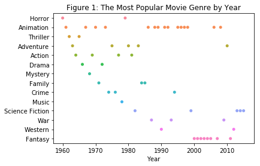

```python
plt.figure()
sns.swarmplot(x='release_year', y='genre', data=df_pop);
plt.title('Figure 1: The Most Popular Movie Genre by Year')
plt.ylabel('')
plt.xlabel('Year')
```

Using a groupby function, I calculate how many years in total a particular genre being the most popular, then I visualize that in a pie chart below.

```
Text(0,0.5,'')
```

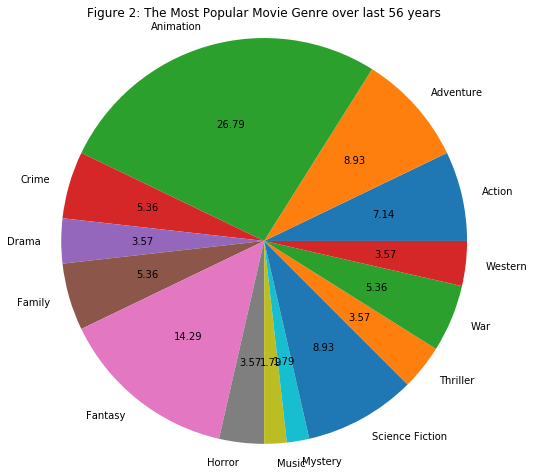

```python
plt.figure(figsize=(8, 8))
ax = df_pop.groupby('genre')['release_year'].count().plot(kind='pie', autopct='%.2f');
plt.title('Figure 2: The Most Popular Movie Genre over last 56 years')
plt.axis('equal')
plt.ylabel('')
```